# Assignment 2 - group 16

Bjarke Dahl Mogensen, Mikkel Mertz og Benjamin Wedel Mathiasen

nov. 2015

# Estimation of bribes in India

This analysis seeks to illuminate the structure of bribes in India. We do this using data from the website ipaidabribe.com. This is a website where people can write if they bribed someone. Peoble are able to inform of various aspects of their bribe such as: how much they paid, where they paid it and to whom. Since the data relies on people to report their bribes themselves we are not observing every bribe, but as long as there isn’t a bias in the data left out this is not going to affect our main conclusions. You might think of it like this: if the older generation does not report any bribes and this subsection of the pupulation bribes peoble for different reasons this would bias our results. However we do not think this is a problem, so we keep to the information availible to us and even if it is only describing a subsection of the population it is still relevant.

## Size of the bribes

When considering the structure of bribes one interesting part to analyze could be the size of the bribes and how much they vary. The mean, median, maximum and minimum of the bribe payments are shown in *table 1*. as we see there is a very big gab between the highest and lowest payment, but its also worth to notice the very big gab between the mean and median.

*Table 1 - Summary statistics*

```
##      Min.   1st Qu.    Median      Mean   3rd Qu.      Max.
## 1.000e+00 2.500e+02 8.000e+02 1.179e+07 3.000e+03 8.120e+09
```

Because of the large variation in the size of the amounts being payed we consider the distribution of payments in *figure 1*. In *figure 1* the density is shown to the log of payments to center it. Even within this transformation the distribuion seems to have a very long tail to the right indicating that the majority of the payments are in the smaller area, but there is a few very large bribes.

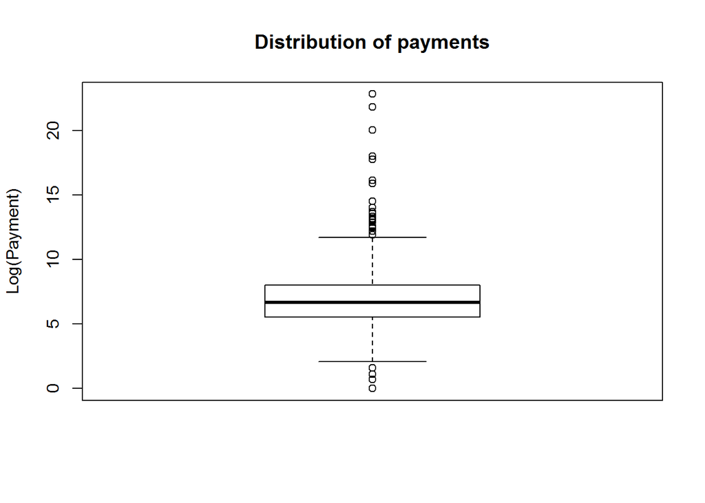

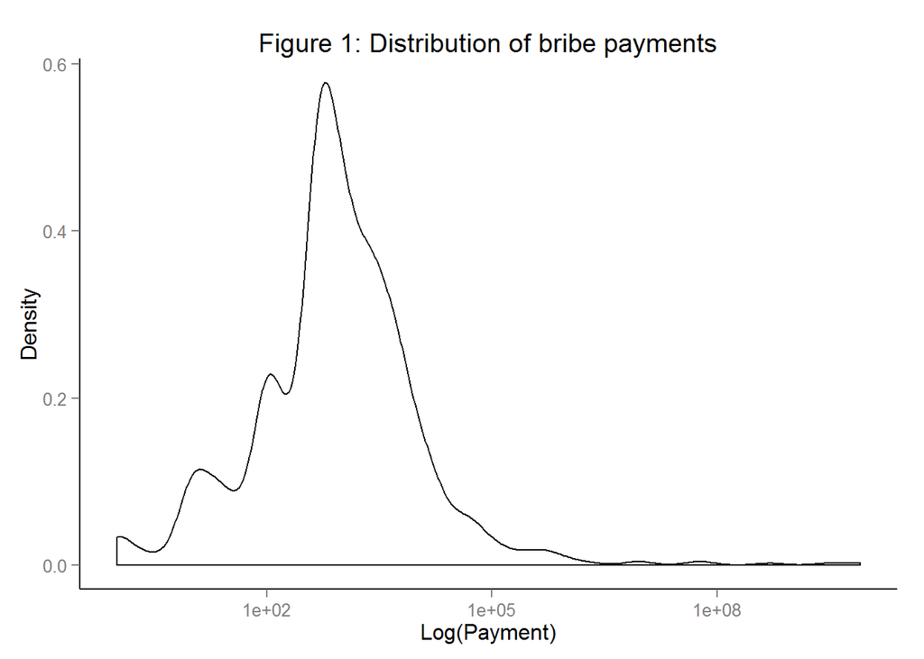

## Number of bribes

As shown above the size of bribes vary a lot, but who primarily receives the bribe and for what? This is what we are going to consider in the next section. In this section we only consider the number of bribes and leaves out the size of the bribe for a moment. *Figure 2* shows the number of bribes reported to each department. Among the departments reported are the police, transportation, municipalities etc.

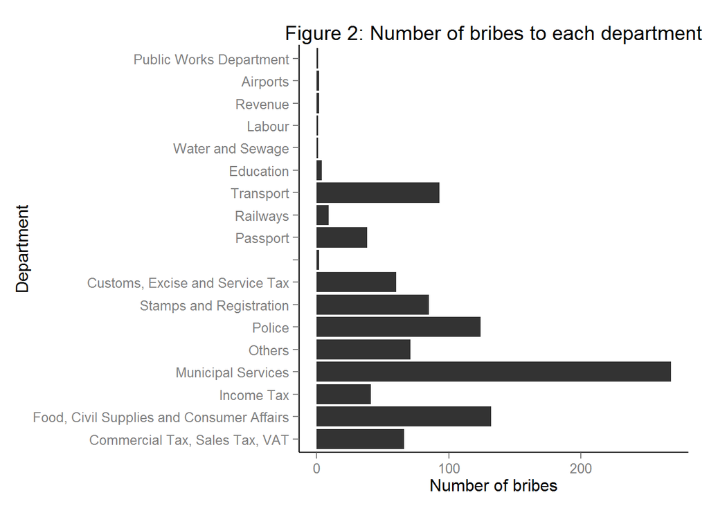

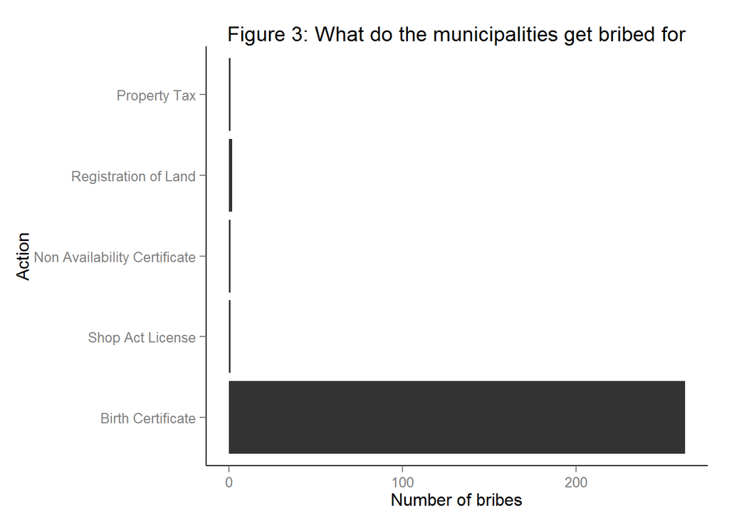

As indicated by *figure 3* the vast majority of the bribes goes to the category “Birth Certificates” and only a very small fraction of the bribes goes to the other categories with the largest being registration of land.

## Size of the bribes in each state

So far we have only considered the overall bribes and size of bribes in entire India. In this section however we dive a little bit more into the different states of India. We want to consider the average sum of payments per 10.000 inhabitants in the different states. This is illustrated in *figure 4* where we plot the logarithmic transformation of the sum of payements per 10.000 individual in each state. As *figure 4* shows there is a great difference in the average payment.

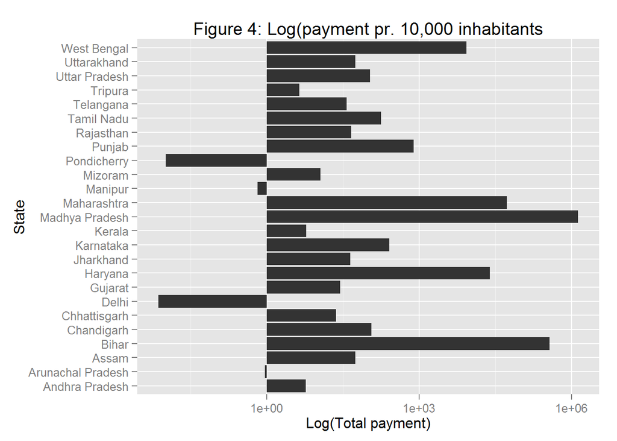